# Video Game Sales — Genre, Platform & Critical Reception Analysis

Sai

June 24, 2026

## Overview

This report analyzes ~16,700 game releases from the Kaggle dataset *“Video Game Sales with Ratings”* (Vgchartz sales data merged with Metacritic critic/user scores). It’s the R/dplyr companion to an Excel workbook covering the same dataset — the genre rollups and best-seller logic below mirror that workbook’s `COUNTIF` / `SUMIF` / `AVERAGEIFS` / `MAXIFS` chain.

```r
vg <- read.csv("/tmp/clean/vg_clean.csv", stringsAsFactors = FALSE)
glimpse(vg)
```

```
## Rows: 16,717
## Columns: 16
## $ Name            <chr> "Wii Sports", "Super Mario Bros.", "Mario Kart Wii", "…
## $ Platform        <chr> "Wii", "NES", "Wii", "Wii", "GB", "GB", "DS", "Wii", "…
## $ Year_of_Release <dbl> 2006, 1985, 2008, 2009, 1996, 1989, 2006, 2006, 2009, …
## $ Genre           <chr> "Sports", "Platform", "Racing", "Sports", "Role-Playin…
## $ Publisher       <chr> "Nintendo", "Nintendo", "Nintendo", "Nintendo", "Ninte…
## $ NA_Sales        <dbl> 41.36, 29.08, 15.68, 15.61, 11.27, 23.20, 11.28, 13.96…
## $ EU_Sales        <dbl> 28.96, 3.58, 12.76, 10.93, 8.89, 2.26, 9.14, 9.18, 6.9…
## $ JP_Sales        <dbl> 3.77, 6.81, 3.79, 3.28, 10.22, 4.22, 6.50, 2.93, 4.70,…
## $ Other_Sales     <dbl> 8.45, 0.77, 3.29, 2.95, 1.00, 0.58, 2.88, 2.84, 2.24, …
## $ Global_Sales    <dbl> 82.53, 40.24, 35.52, 32.77, 31.37, 30.26, 29.80, 28.92…
## $ Critic_Score    <dbl> 76, NA, 82, 80, NA, NA, 89, 58, 87, NA, NA, 91, NA, 80…
## $ Critic_Count    <dbl> 51, NA, 73, 73, NA, NA, 65, 41, 80, NA, NA, 64, NA, 63…
## $ User_Score      <dbl> 8.0, NA, 8.3, 8.0, NA, NA, 8.5, 6.6, 8.4, NA, NA, 8.6,…
## $ User_Count      <dbl> 322, NA, 709, 192, NA, NA, 431, 129, 594, NA, NA, 464,…
## $ Developer       <chr> "Nintendo", "", "Nintendo", "Nintendo", "", "", "Ninte…
## $ Rating          <chr> "E", "", "E", "E", "", "", "E", "E", "E", "", "", "E",…
```

## Genre Insights

Excel computes, per genre: game count (`COUNTIF`), total global sales (`SUMIF`), average critic/user score (`AVERAGEIFS`), and the single best-selling title (`MAXIFS` to find the top sales figure, then a `SUMPRODUCT` row-finder to locate which title that belongs to — a workaround for the fact that Excel has no native “return the row where X is max”). dplyr’s `slice_max()` does that last step directly — this is one place where the spreadsheet needs a multi-formula workaround for something the code tool does natively.

```r
genre_summary <- vg %>%
  group_by(Genre) %>%
  summarise(
    Games = n(),
    Total_Global_Sales_M = sum(Global_Sales, na.rm = TRUE),
    Avg_Critic_Score = mean(Critic_Score, na.rm = TRUE),
    Avg_User_Score_x10 = mean(User_Score, na.rm = TRUE) * 10,
    .groups = "drop"
  ) %>%
  arrange(desc(Total_Global_Sales_M))

best_sellers <- vg %>%
  group_by(Genre) %>%
  slice_max(Global_Sales, n = 1, with_ties = FALSE) %>%
  select(Genre, Best_Seller = Name, Best_Seller_Sales_M = Global_Sales)

genre_summary <- genre_summary %>% left_join(best_sellers, by = "Genre")
genre_summary
```

| Genre | Games | Total_Global_Sales_M | Avg_Critic_Score | Avg_User_Score_x10 | Best_Seller | Best_Seller_Sales_M |
| --- | --- | --- | --- | --- | --- | --- |
| Action | 3370 | 1745.27 | 66.62910 | 70.54044 | Grand Theft Auto V | 21.04 |
| Sports | 2348 | 1332.00 | 71.96817 | 69.61197 | Wii Sports | 82.53 |
| Shooter | 1323 | 1052.94 | 70.18114 | 70.41883 | Duck Hunt | 28.31 |
| Role-Playing | 1500 | 934.40 | 72.65265 | 76.19515 | Pokemon Red/Pokemon Blue | 31.37 |
| Platform | 888 | 828.08 | 68.05835 | 73.01402 | Super Mario Bros. | 40.24 |
| Misc | 1750 | 803.18 | 66.61950 | 68.19362 | Wii Play | 28.92 |
| Racing | 1249 | 728.90 | 67.96361 | 70.36193 | Mario Kart Wii | 35.52 |
| Fighting | 849 | 447.48 | 69.21760 | 73.02506 | Super Smash Bros. Brawl | 12.84 |
| Simulation | 874 | 390.42 | 68.61932 | 71.34593 | Nintendogs | 24.67 |
| Puzzle | 580 | 243.02 | 67.42411 | 71.75000 | Tetris | 30.26 |

[output cut: 2 more lines]

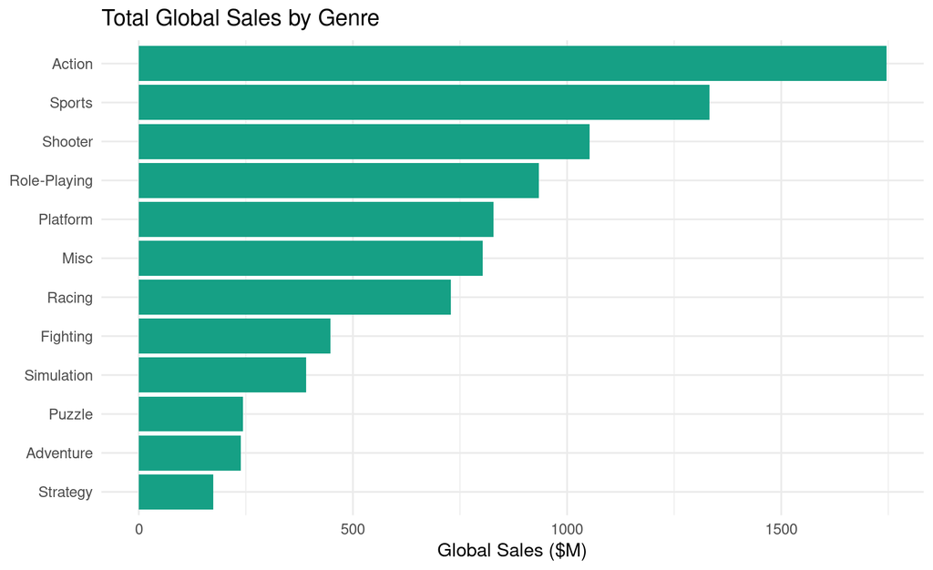

```r
ggplot(genre_summary, aes(x = reorder(Genre, Total_Global_Sales_M), y = Total_Global_Sales_M)) +
  geom_col(fill = "#16A085") +
  coord_flip() +
  labs(title = "Total Global Sales by Genre", x = NULL, y = "Global Sales ($M)") +
  theme_minimal(base_size = 13)
```

## Critical Reception vs. Commercial Success

Mirrors the Excel “Genre Insights” scatter chart (critic score vs. avg user score, bubble-sized implicitly by genre) — same two-variable comparison, built natively with `geom_point()` instead of an Excel `ScatterChart` object.

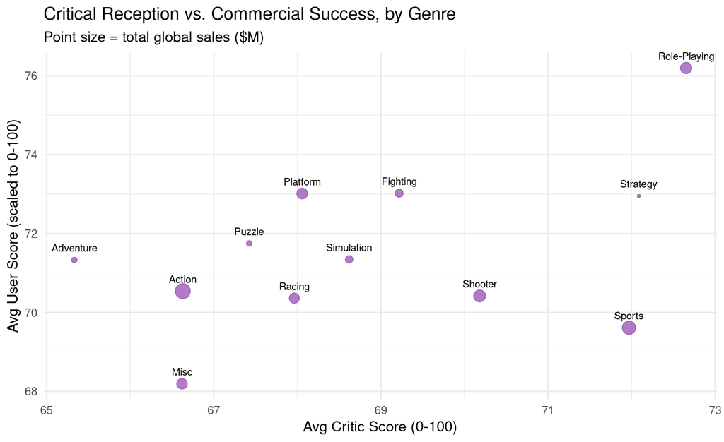

```r
ggplot(genre_summary, aes(x = Avg_Critic_Score, y = Avg_User_Score_x10, label = Genre)) +
  geom_point(aes(size = Total_Global_Sales_M), color = "#8E44AD", alpha = 0.7) +
  geom_text(vjust = -1.1, size = 3.2) +
  labs(title = "Critical Reception vs. Commercial Success, by Genre",
       subtitle = "Point size = total global sales ($M)",
       x = "Avg Critic Score (0-100)", y = "Avg User Score (scaled to 0-100)") +
  theme_minimal(base_size = 13) +
  theme(legend.position = "none")
```

## Release-Year Trend

Mirrors the Excel “Release Trends” sheet’s `COUNTIF` (titles released per year) and its companion sales-per-year line. The dataset’s tail years (2017+) are sparse/incomplete in the source file, so they’re dropped to avoid a misleading end-of-line dip.

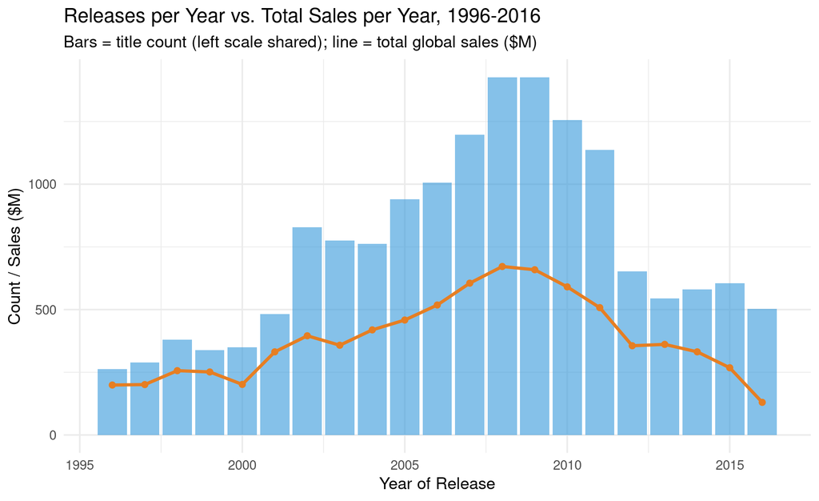

```r
year_summary <- vg %>%
  filter(!is.na(Year_of_Release), Year_of_Release >= 1996, Year_of_Release <= 2016) %>%
  group_by(Year_of_Release) %>%
  summarise(Releases = n(), Total_Sales_M = sum(Global_Sales, na.rm = TRUE), .groups = "drop")

ggplot(year_summary, aes(x = Year_of_Release)) +
  geom_col(aes(y = Releases), fill = "#3498DB", alpha = 0.6) +
  geom_line(aes(y = Total_Sales_M), color = "#E67E22", size = 1.2) +
  geom_point(aes(y = Total_Sales_M), color = "#E67E22", size = 2) +
  labs(title = "Releases per Year vs. Total Sales per Year, 1996-2016",
       subtitle = "Bars = title count (left scale shared); line = total global sales ($M)",
       x = "Year of Release", y = "Count / Sales ($M)") +
  theme_minimal(base_size = 13)
```

## Top Publishers by Total Sales

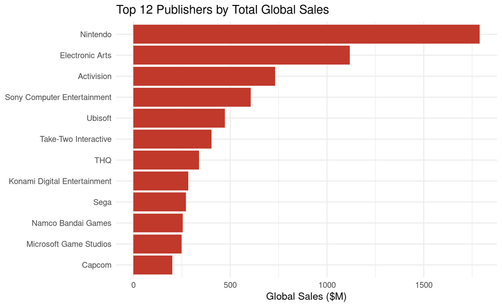

```r
top_publishers <- vg %>%
  group_by(Publisher) %>%
  summarise(Games = n(), Total_Sales_M = sum(Global_Sales, na.rm = TRUE), .groups = "drop") %>%
  filter(Publisher != "") %>%
  arrange(desc(Total_Sales_M)) %>%
  slice_head(n = 12)

ggplot(top_publishers, aes(x = reorder(Publisher, Total_Sales_M), y = Total_Sales_M)) +
  geom_col(fill = "#C0392B") +
  coord_flip() +
  labs(title = "Top 12 Publishers by Total Global Sales", x = NULL, y = "Global Sales ($M)") +
  theme_minimal(base_size = 13)
```

## Platform Mix Within Top Genres

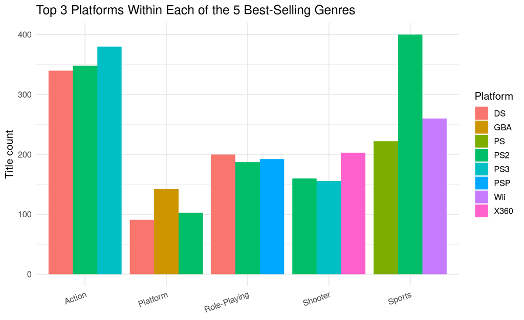

```r
top_genres <- genre_summary$Genre[1:5]

vg %>%
  filter(Genre %in% top_genres) %>%
  count(Genre, Platform) %>%
  group_by(Genre) %>%
  slice_max(n, n = 3, with_ties = FALSE) %>%
  ungroup() %>%
  ggplot(aes(x = Genre, y = n, fill = Platform)) +
  geom_col(position = "dodge") +
  labs(title = "Top 3 Platforms Within Each of the 5 Best-Selling Genres",
       x = NULL, y = "Title count") +
  theme_minimal(base_size = 13) +
  theme(axis.text.x = element_text(angle = 20, hjust = 1))
```

## Takeaways

*Data source: Kaggle — “Video Game Sales with Ratings” (Vgchartz sales data merged with Metacritic critic/user scores).*